# Homework IV, ES207

Amir Sharafi

02/18/2020

## Question 3.1

First, check the normality of the data by plotting it in the histogram transformation mode.

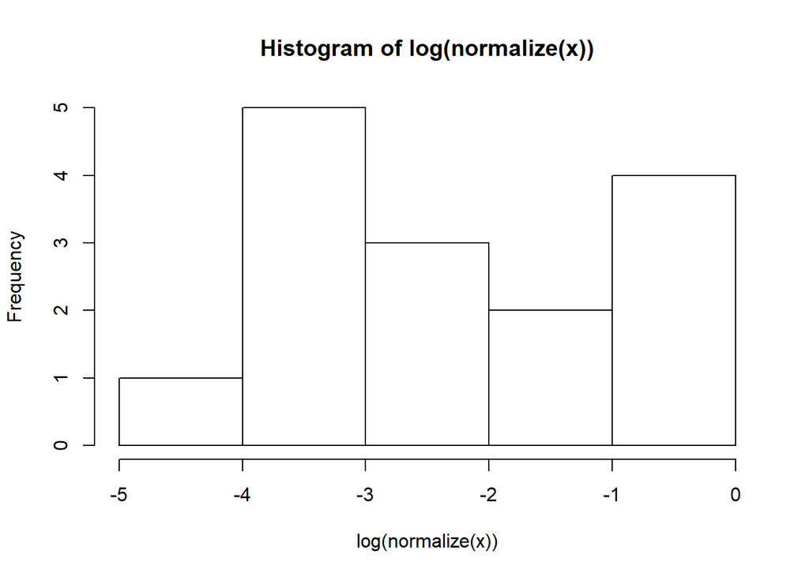

```r
# create the sample data of chloride concentration, in mg/L
x <- c(6.0, 0.5, 0.4, 0.7, 0.8, 6.0,
       5.0, 0.6, 1.2, 0.3, 0.2, 0.5,
        0.5, 10, 0.2, 0.2, 1.7, 3.0)# Granodiorite
# Data visualization
hist(log(normalize(x)))
```

Since the data is skewed and we do not see a normal distribution in the data, so non-parametric interval estimate would be a better estimation

```r
# nonparametric 95% interval estimates with quantile function and your method
bstrap <- c()
# Do the iteration for making the vector of means samples.
for (i in 1:1000){
bstrap <- c(bstrap, mean(sample(x, 8, replace = T)))
}
alfa <- 1-.95
lo_np <- quantile(bstrap,alfa/2) #lower band
up_np <- quantile(bstrap, 1-alfa/2) #upper band
print(paste0("(", round(lo_np,3), ", ", round(up_np,3), ")"))
```

```
## [1] "(0.525, 4.25)"
```

Nonparametric 95% interval estimates with book online table (table B5)

```r
# parametric 95% interval estimates median
#Natural log of x , the method is from book
y <- log(x)
me <- qt(0.975,length(y)-1)*sd(y)/sqrt(length(y))
lo_p_ln <- mean(y)-me #lower band
up_p_ln <- mean(y)+me
lo_p <- exp(lo_p_ln)
up_p <- exp(up_p_ln)

print(paste0("For median","(", round(lo_p,3), ", ", round(up_p,3), ")"))
```

```
## [1] "For median(0.506, 1.804)"
```

```r
# Parametric by using function 'predict'for mean
CI <- predict(lm(x~1),
              interval = "confidence",
              level = 0.95)
print(paste0("For mean"))
```

```
## [1] "For mean"
```

```r
CI[1,]
```

```
##       fit       lwr       upr
## 2.1000000 0.7061309 3.4938691
```

By the way, the non-parametric interval estimate result is a wider interval.

## Question 3.4

Check the normality of the data by plotting it in the histogram transformation mode too find the appropriate estimation method.

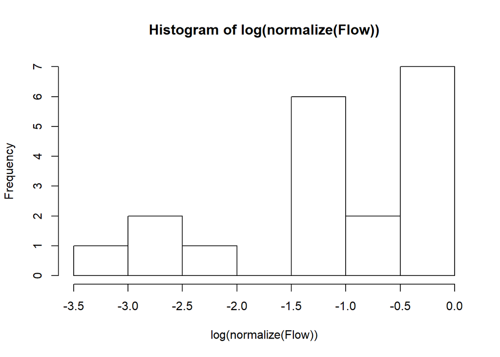

```r
# first call the data
Con_river <- read_csv("~/Desktop/ES207/HW/es207_hw4/Conecuh_River_apxc2.csv",
                       col_names =TRUE,
                      cols(
  Year = col_double(),
  `Flow (cfs)` = col_double()
))
# Data visualization
Flow <- na.omit(Con_river$`Flow (cfs)`)
hist(log(normalize(Flow))) #plot normalized data
```

Since the data does not have a normal distribution or data is Asymmetric, so non-parametric interval estimate would be a better median estimation. And one-sided estimation for the Confidence Interval for the mean.

```r
# nonparametric 95% interval estimates median?
bstrap <- c()
for (i in 1:1000){
bstrap <- c(bstrap, mean(sample(Flow, 5, replace = T)))# create vector of means
}
alfa <- 1-.95
lo_np_4 <- quantile(bstrap,alfa/2) # lower band
up_np_4 <- quantile(bstrap, 1-alfa/2) #upper band
print(paste0("(", round(lo_np_4,3), ", ", round(up_np_4,3), ")"))
```

```
## [1] "(465.135, 922.235)"
```

Nonparametric 95% interval estimates with book online table (table B5)

According the online table -> x’=5 -> Rl=5+1 & Ru=20-5 So 524< C0.5 < 894

```r
#Asymmetric Confidence Interval for the mean
# again use the natural log
y <- log(Flow)
Mean_y <- mean(y)
SD_y <- sd(y)
Mean_Flow <- exp(Mean_y+0.5*SD_y^2) # apply the formula from the book
Mean_Flow
```

```
## [1] 686.563
```

Since I could not find the interval estimation ( there is point estimation) for mean in the book, I calculated the symmetric method for CI too.

```r
#symmetric Confidence Interval for the mean
# I do this to just find the inetrval
# parametric 95% interval estimates for mean
me <- qt(0.975,length(Flow)-1)*sd(Flow)/sqrt(length(Flow))
lo_p <- mean(Flow)-me
up_p <- mean(Flow)+me
#print the result
print(paste0("(", round(lo_p,3), ", ", round(up_p,3), ")"))
```

```
## [1] "(556.613, 808.887)"
```

Our estimated mean is in the interval.

## Question 4 from Qian

The first step of a comparison of the two populations is to examine the possible nature of the difference. Using data from 1994, we compare the two data sets using a Q-Q plot. For tp less than 30 we have

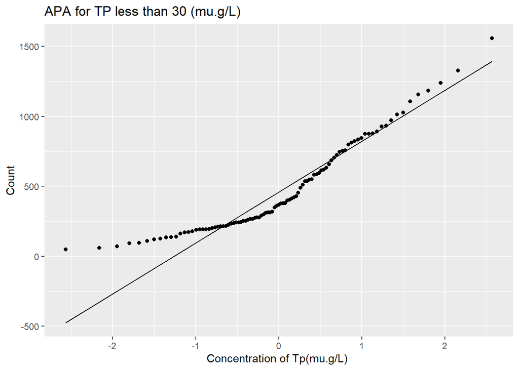

```r
TP2 <- apa.dat %>% filter(tp < 30 )
ggplot(TP2, mapping = aes(sample = `apa`, col = tp)) +
    geom_qq(na.rm = T) + geom_qq_line(na.rm = T)+
    labs(title = "APA for TP less than 30 (mu.g/L)") +
labs(x = "Concentration of Tp(mu.g/L) ", y = "Count")
```

According to the relation of curve and line, we may say this data in some parts (not outliers more middle) are likely additive.

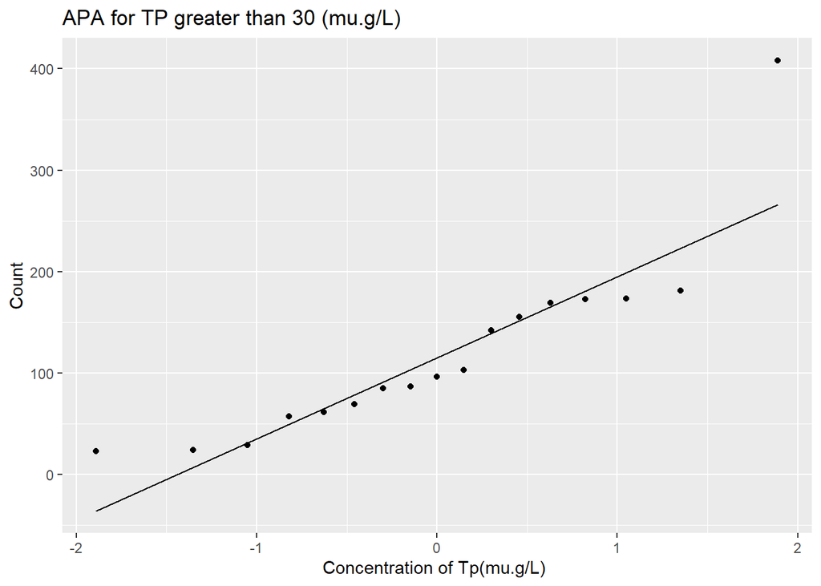

```r
TP1 <- apa.dat %>% filter(tp >= 30 )
ggplot(TP1, mapping = aes(sample = `apa`, col = tp)) +
    geom_qq(na.rm = T) + geom_qq_line(na.rm = T)+
  labs(title = "APA for TP greater than 30 (mu.g/L)") +
labs(x = "Concentration of Tp(mu.g/L) ", y = "Count")
```

The same reason we can say this additive to but, the number of samples here is small, so our conclusion could not be proper as the ‘APA’ of less than 30. B) About the nature of difference regards the above curves, I can say, TP concentrations are likely multiplicative between to sets of data according to Q_Q plot of them toghter.Regards the relationship between dots and line,hard to find the relation between those two sets of data. (following picture)

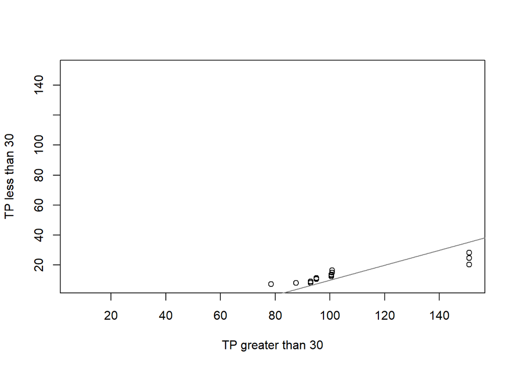

```r
x.data <- TP1[,2]
y.data <- TP2[,2]
# create the qqplot
qqplot(x.data, y.data, xlim=range(c(x.data,y.data)),
       ylim=range(c(x.data,y.data)), xlab="TP greater than 30", ylab="TP less than 30")
#draw the line
abline(-40,.5, col=grey(0.5))
```

3. “Quantifying the difference in the two population means will be sufficient in describing the difference between the populations.” helsel_hirsch “To test whether the two population mean is different or not, we set the two competing hypotheses , null and alternative hypotheses.” helsel_hirsch So, according to the above sentences, I will check the alternative and null hypotheses. by t-test function

```r
# Finde the existance of  null and alternative  hypotheses
t.test(x=TP2, y=TP1, alternative="greater", var.equal=T)
```

```
##
##  Two Sample t-test
##
## data:  TP2 and TP1
## t = 2.3254, df = 226, p-value = 0.01047
## alternative hypothesis: true difference in means is greater than 0
## 95 percent confidence interval:
##  38.26761      Inf
## sample estimates:
## mean of x mean of y
##  244.1193  112.0399
```

It seams alternative hypothesis is true and they are different. As we expected. In my opinion, there should be human activities that emit the phosphorus to the environment, near those for the TP greater than the 30 mu.g/L, So those activities interfere with the sampling procedure.